# RAPM Experiments Data Analysis

Andrea Stocco

August 11, 2019

# RAPM Experiments analysis

```r
plot.correlations.size <- function(data, xvar, yvar, xlab=xvar, ylab=yvar, leg=F, legpos="bottom", corpos=c(0.2, 0.2), xlim=c(0, 1), legcols=NA, ...) {
  attach(data)
  mod <- lm(as.formula(paste(yvar, xvar, sep="~")))

  range <- (xlim[2] - xlim[1])
  newx <- data.frame(X=seq(xlim[1] - 1/2 *range, xlim[2] + 1/2 * range, range/1000))
  names(newx) <- c(xvar)  # Rename to X variable in data frame
  newy <- predict(mod, newdata=newx, interval="confidence", level=0.95)
  detach(data)
  k <- data
  k$Count <- 0
  kz <- aggregate(k$Count, list(xvar=k[[xvar]], yvar=k[[yvar]]), length)
  #print(kz$x)
  plot(kz$xvar, kz$yvar, pch=21, bg="white", col="white", cex=kz$x,
       fg="grey15", xlab="", ylab="", col.axis="grey15", col.lab="grey15", xlim=xlim, ...)
  p <- cor.test(data[[xvar]], data[[yvar]])$p.value
  significance = ""
  if (p < 0.05) {
    line <- "red"
    shade <- "#FF222222"
    significance = "*"
    if (p < 0.01) {significance = "**"}
    if (p < 0.001) {significance = "***"}
  } else {
    line <- "black"
    shade <- "#22222222"
  }
  bgs=c("#77777799", "#44444499", "#11111199", "#11111199")
  polygon(c(newx[[xvar]], rev(newx[[xvar]])), c(newy[,2], rev(newy[,3])), col=shade, border=F)
  points(kz$xvar, kz$yvar, pch=21, bg=sapply(kz$x, function(x){bgs[x]}), col="white", cex=1.5 * sqrt(kz$x),
       fg="grey15", xlab="", ylab="", col.axis="grey15", col.lab="grey15", xlim=xlim, ...)
  #points(data[[xvar]], data[[yvar]], pch=21, bg="#11111166", col="white", cex=1.5)
  abline(mod, col=line, lwd=2, lty=3)

  r <- round(cor(data[[xvar]], data[[yvar]]), 2)
  #detach(data)
  text(x=corpos[1], y=corpos[2], col=line, labels=substitute(italic(r)(n) == x~s, list(n=length(data[[xvar]]), x=r, s=significance)))
  mtext(ylab, side=2, line=2, col="grey15")
  mtext(xlab, side=1, line=2, col="grey15")
  if (leg) {
    if (is.na(legcols)) {legcols <- max(kz$x)}
    legend(x=legpos, ncol=legcols, legend=paste("n=", sep="", sort(unique(kz$x))), pch=21,
           col="white", pt.bg=sapply(unique(kz$x), function(x){bgs[x]}), pt.cex= 1.5*sqrt(unique(kz$x)),
           bg="#CCCCCC88", box.col = NA)
  }
  box(bty="O")
}
```

## Experiment 1

### Demographics

Here are summary data about the age distributions by gender:

```r
demo1 <- read.table("experiment1/demographics.txt", header=T)
demo1 %>%
  group_by(Gender) %>%
  summarise(N=length(Age), MeanAge=mean(Age), SDAge=sd(Age)) %>%
  kable(digits = 3) %>%
  kable_styling(bootstrap_options = c("striped", "hover"))
```

| Gender | N | MeanAge | SDAge |
| --- | --- | --- | --- |
| Female | 53 | 20.396 | 3.078 |
| Male | 44 | 20.159 | 2.693 |

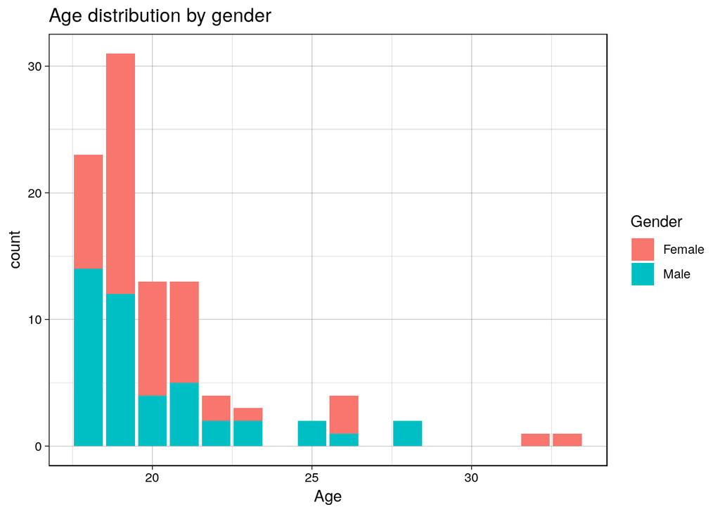

```r
ggplot(demo1, aes(x=Age, fill=Gender)) +
  geom_bar() +
  theme_linedraw() +
  ggtitle("Age distribution by gender")
```

### Loading the data

The data summary is contanted in the `experiment1` file:

```r
behav1 <- read.table("experiment1.txt", header=T, sep="\t")

# Remove all the participants for which we do not have complete data
#
behav1 <- subset(behav1, !is.na(behav1$RAPM)
                 & !is.na(behav1$AvoidB)
                 & !is.na(behav1$ChooseA)
                 & !is.na(behav1$OS_Score))
```

Because Experiments 1-3 have different number of problems, we are going to normalize the performance variable as the proportion of correct problems solved. This will make sure all the correlations are on the same scale.

```r
behav1$RAPM_Accuracy <- behav1$RAPM / 34
```

There are four behavioral variables of interest in this data. Avoid accuracy (`AvoidB`) and Choose accuracy (`ChooseA`) come from the PSS task; Operation Span (`OS_Score`) comes from the Operation Span task; and RAPM Accuracy (`RAPM_Accuracy`) comes from the Raven’s Advanced Progressive Matrices test.

```r
vars_of_interest <- c("ChooseA", "AvoidB", "OS_Score", "RAPM_Accuracy")
```

### Descriptive statistics

Given this, we can look at some basic features. First, we can look at the distribution of the four variables:

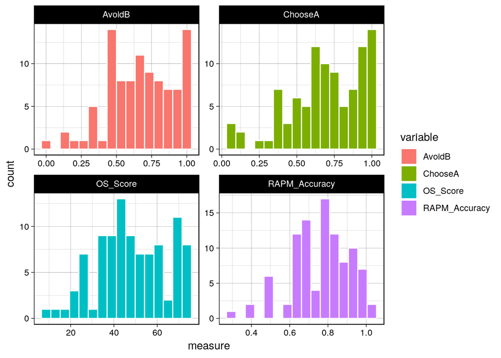

```r
longb1 <- gather(behav1, variable, measure, vars_of_interest)
ggplot(longb1, aes(measure, fill=variable)) +
  geom_histogram(col=I("white"), bins = 16) +
  facet_wrap( . ~ variable, scales= "free") +
  theme_linedraw()
```

Second, let’s look at their mean values:

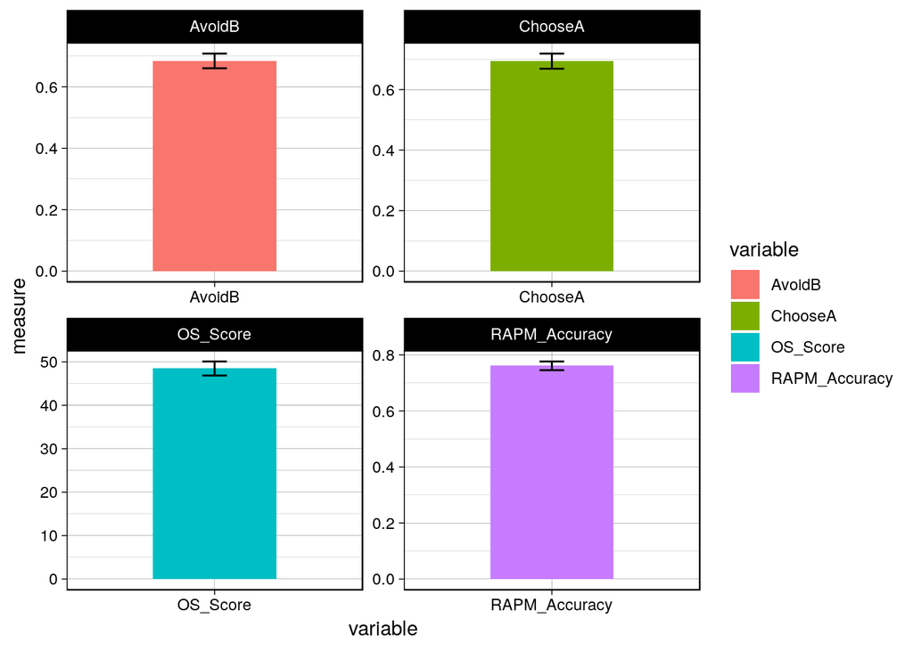

```r
ggplot(longb1, aes(x=variable, y=measure, fill=variable)) +
  stat_summary(fun.data="mean_se", geom = "bar", width=0.5) +
  stat_summary(fun.data="mean_se", geom = "errorbar", width=0.1) +
  facet_wrap( . ~ variable, scales= "free") +
  theme_linedraw()
```

And, finally, let’s summarize their means and SDs in a table:

```r
longb1 %>%
  group_by(variable) %>%
  summarise(N=length(measure), Mean=mean(measure), SD=sd(measure)) %>%
  kable(digits = 3) %>%
  kable_styling(bootstrap_options = c("striped", "hover"))
```

| variable | N | Mean | SD |
| --- | --- | --- | --- |
| AvoidB | 97 | 0.684 | 0.235 |
| ChooseA | 97 | 0.694 | 0.246 |
| OS_Score | 97 | 48.474 | 15.911 |
| RAPM_Accuracy | 97 | 0.761 | 0.153 |

### A comparison of Choose and Avoid accuracies

As expected, the mean values of Choose (*M* = 0.694, *SD* = 0.246) and Avoid (*M* = 0.684, *SD* = 0.235) are approximately the same. A *t*-test shows no difference between the two values:

```r
t <- t.test(behav1$ChooseA, behav1$AvoidB, paired = T)
```

with *t*(96) = 0.31 *p* = 0.761.

### Correlations between variables

First, we can examine the correlation matrix between these varibles:

```r
cor(behav1[vars_of_interest]) %>%
  kable(digits = 3) %>%
  kable_styling(bootstrap_options = c("striped", "hover"))
```

|  | ChooseA | AvoidB | OS_Score | RAPM_Accuracy |
| --- | --- | --- | --- | --- |
| ChooseA | 1.000 | 0.163 | 0.181 | 0.127 |
| AvoidB | 0.163 | 1.000 | 0.246 | 0.344 |
| OS_Score | 0.181 | 0.246 | 1.000 | 0.215 |
| RAPM_Accuracy | 0.127 | 0.344 | 0.215 | 1.000 |

We can also calculate the correspinding *p*-values:

```r
behav1[vars_of_interest] %>%
  as.matrix() %>%
  rcorr() -> pvals

pvals$P %>%
  kable(digits = 3) %>%
  kable_styling(bootstrap_options = c("striped", "hover"))
```

|  | ChooseA | AvoidB | OS_Score | RAPM_Accuracy |
| --- | --- | --- | --- | --- |
| ChooseA | NA | 0.110 | 0.077 | 0.216 |
| AvoidB | 0.110 | NA | 0.015 | 0.001 |
| OS_Score | 0.077 | 0.015 | NA | 0.034 |
| RAPM_Accuracy | 0.216 | 0.001 | 0.034 | NA |

And finally, we can examine the scatterplots of the correlations between variables:

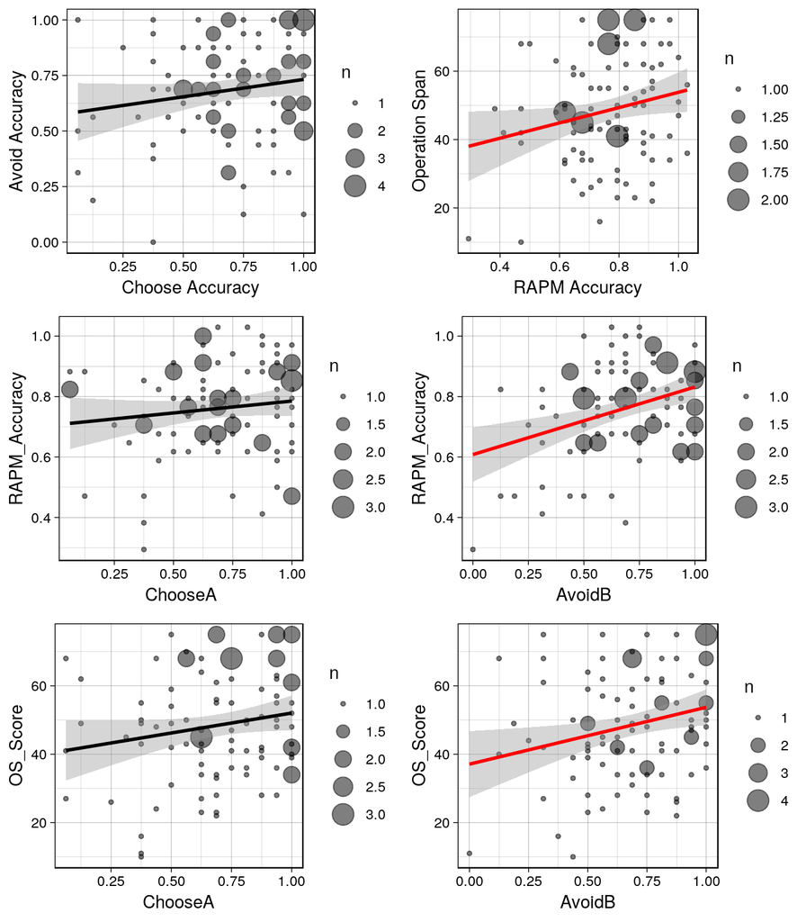

```r
sp1 <- ggplot(behav1, aes(x = ChooseA, y = AvoidB)) +
  #stat_bin_hex(bins=16, col="white") +
  geom_count(alpha = 0.5) +
  geom_smooth(method = "lm", formula = y ~ x, col="black", fullrange= T) +
  xlab("Choose Accuracy") +
  ylab("Avoid Accuracy") +
  theme_linedraw()

sp2 <- ggplot(behav1, aes(x = RAPM_Accuracy, y = OS_Score)) +
#  stat_bin_hex(bins=16, col="white") +
  geom_count( alpha = 0.5) +
  geom_smooth(method = "lm", formula = y ~ x, col="red", fullrange= T) +
  xlab("RAPM Accuracy") +
  ylab("Operation Span") +
  theme_linedraw()

sp3 <- ggplot(behav1, aes(x = ChooseA, y = RAPM_Accuracy)) +
  #stat_bin_hex(bins=16, col="white") +
  geom_count( alpha = 0.5) +
  geom_smooth(method = "lm", formula = y ~ x, col="black", fullrange= T) +
  theme_linedraw()

sp4 <- ggplot(behav1, aes(x = AvoidB, y = RAPM_Accuracy)) +
  #stat_bin_hex(bins=16, col="white") +
  geom_count(alpha = 0.5) +
  geom_smooth(method = "lm", formula = y ~ x, col="red", fullrange= T) +
  theme_linedraw()

sp5 <- ggplot(behav1, aes(x = ChooseA, y = OS_Score)) +
  #stat_bin_hex(bins=16, col="white") +
  geom_count(alpha=0.5) +
  geom_smooth(method = "lm", formula = y ~ x, col="black", fullrange= T) +
  theme_linedraw()

sp6 <- ggplot(behav1, aes(x = AvoidB, y = OS_Score)) +
  #stat_bin_hex(bins=16, col="white") +
  geom_count(alpha=0.5) +
  geom_smooth(method = "lm", formula = y ~ x, col="red", fullrange= T) +
  theme_linedraw()

grid.arrange(sp1, sp2, sp3, sp4, sp5, sp6, nrow = 3)
```

## Experiment 2

Experiment 2 was a replication of Experiment 1, only using the Brief Abbreviated version of the RAPM task instead of the full version. The Brief RAPM was also performed on a computer. Because of attrition, a large amount of participants could not complete the Operation Span task.

### Demographics

Here are summary data about the age distributions by gender:

```r
demo2 <- read.table("experiment2/demographics.txt", header=T)
demo2 %>%
  group_by(Gender) %>%
  summarise(N=length(Age), MeanAge=mean(Age), SDAge=sd(Age)) %>%
  kable(digits = 3) %>%
  kable_styling(bootstrap_options = c("striped", "hover"))
```

| Gender | N | MeanAge | SDAge |
| --- | --- | --- | --- |
| Female | 41 | 19.585 | 2.025 |
| Male | 42 | 19.548 | 1.383 |

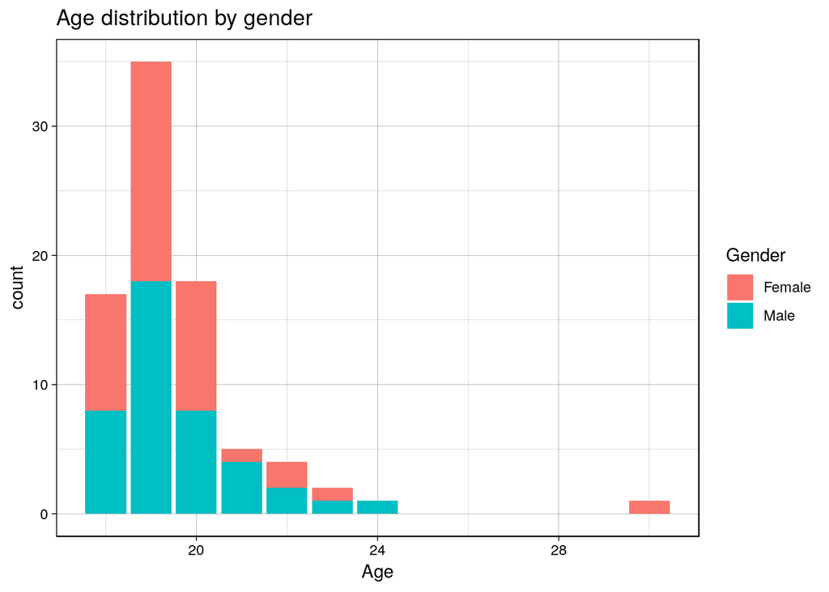

```r
ggplot(demo2, aes(x=Age, fill=Gender)) +
  geom_bar() +
  theme_linedraw() +
  ggtitle("Age distribution by gender")
```

### Loading the data

First, we are going to load the results from Experiment 2 in “wide” summary format.

```r
behav2 <- read.table("experiment2.txt", header=T, sep="\t")
```

We are then going to remove all of the participants for whom we do not have RAPM or PSS data:

```r
behav2 <- subset(behav2,
                 !is.na(behav2$BARAPM) &
                   !is.na(behav2$AvoidB))
```

Finally, for consistency, we are going to create a new variable `RAPM_Accuracy` represents the proportion of correct responses.

```r
behav2$RAPM_Accuracy <- behav2$BARAPM / 12
```

```r
behav2 <- subset(behav2, behav2$BARAPM > 2 )
```

In this experiment, we do not have sufficient data from AOSPAN, so we are going to focus only on three variables of interest:

```r
vars_of_interest <- c("ChooseA", "AvoidB", "RAPM_Accuracy") # No OS Score
```

### Descriptive statistics

As before, let’s first look at their distribution:

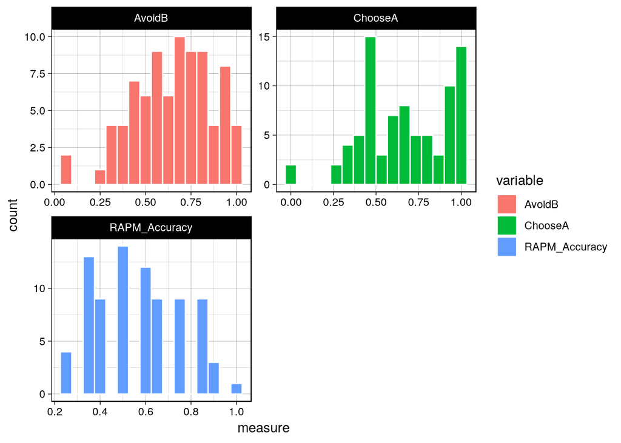

```r
longb2 <- gather(behav2, variable, measure, vars_of_interest)
ggplot(longb2, aes(measure, fill=variable)) +
  geom_histogram(col=I("white"), bins = 16) +
  facet_wrap( . ~ variable, nrow = 2, scales= "free") +
  theme_linedraw()
```

Like before, let’s look at their mean values:

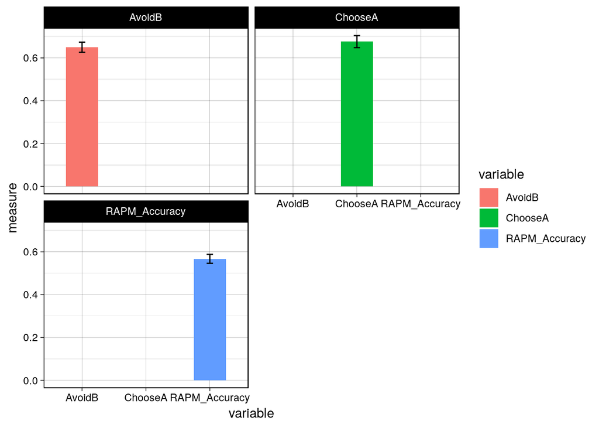

```r
ggplot(longb2, aes(x=variable, y=measure, fill=variable)) +
  stat_summary(fun.data="mean_se", geom = "bar", width=0.5) +
  stat_summary(fun.data="mean_se", geom = "errorbar", width=0.1) +
  facet_wrap( . ~ variable, nrow = 2) +
  theme_linedraw()
```

And here is a summary of their means and SDs in a table:

```r
longb2 %>%
  group_by(variable) %>%
  summarise(N=length(measure), Mean=mean(measure), SD=sd(measure)) %>%
  kable(digits = 3) %>%
  kable_styling(bootstrap_options = c("striped", "hover"))
```

| variable | N | Mean | SD |
| --- | --- | --- | --- |
| AvoidB | 83 | 0.650 | 0.216 |
| ChooseA | 83 | 0.676 | 0.255 |
| RAPM_Accuracy | 83 | 0.567 | 0.190 |

### A comparison of Choose and Avoid accuracies

As expected, the mean values of Choose (*M* = 0.676, *SD* = 0.255) and Avoid (*M* = 0.65, *SD* = 0.216) are approximately the same. A *t*-test shows no difference between the two values:

```r
t <- t.test(behav2$ChooseA, behav2$AvoidB, paired = T)
```

with *t*(82) = 0.7056856, *p* = 0.4823837.

### Correlations between variables

First, we can examine the correlation matrix between these varibles:

```r
cor(behav2[vars_of_interest]) %>%
  kable(digits = 3) %>%
  kable_styling(bootstrap_options = c("striped", "hover"))
```

|  | ChooseA | AvoidB | RAPM_Accuracy |
| --- | --- | --- | --- |
| ChooseA | 1.000 | -0.037 | -0.144 |
| AvoidB | -0.037 | 1.000 | 0.236 |
| RAPM_Accuracy | -0.144 | 0.236 | 1.000 |

We can also calculate the correspinding *p*-values:

```r
behav2[vars_of_interest] %>%
  as.matrix() %>%
  rcorr() -> pvals

pvals$P %>%
  kable(digits = 3) %>%
  kable_styling(bootstrap_options = c("striped", "hover"))
```

|  | ChooseA | AvoidB | RAPM_Accuracy |
| --- | --- | --- | --- |
| ChooseA | NA | 0.738 | 0.194 |
| AvoidB | 0.738 | NA | 0.032 |
| RAPM_Accuracy | 0.194 | 0.032 | NA |

And finally, we can examine the scatterplots of the correlations between variables:

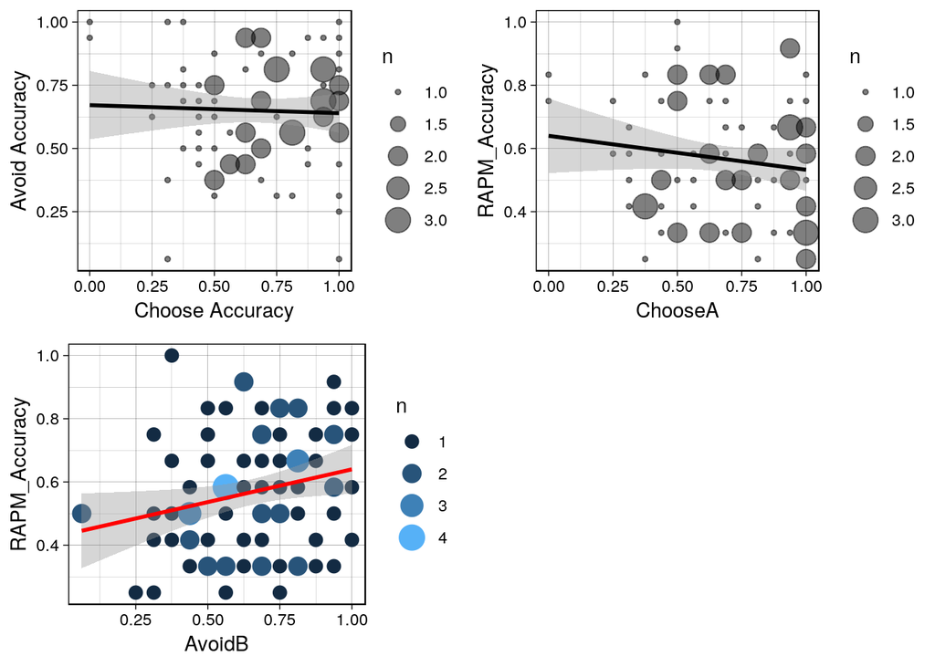

```r
sp1 <- ggplot(behav2, aes(x = ChooseA, y = AvoidB)) +
  #stat_bin_hex(bins=16, col="white") +
  geom_count(alpha = 0.5) +
  geom_smooth(method = "lm", formula = y ~ x,
              col="black", fullrange= T) +
  xlab("Choose Accuracy") +
  ylab("Avoid Accuracy") +
  theme_linedraw()

sp2 <- ggplot(behav2, aes(x = ChooseA, y = RAPM_Accuracy)) +
  #stat_bin_hex(bins = 12, col="white") +
  geom_count(alpha =0.5) +
  geom_smooth(method = "lm", formula = y ~ x,
              col="black", fullrange= T) +
  theme_linedraw()

sp3 <- ggplot(behav2, aes(x = AvoidB, y = RAPM_Accuracy)) +
  #stat_bin_hex(bins = 12, col="white") +
  geom_count(aes(colour= ..n.., size= ..n..)) +
  guides(color='legend') +
  scale_size_area() +
  geom_smooth(method = "lm", formula = y ~ x,
              col="red", fullrange= T) +
  theme_linedraw()

grid.arrange(sp1, sp2, sp3, nrow = 2)
```

## Experiment 3

Experiment 3 was conducted in the fMRI scanner. In addition to the behavioral data, we have fMRI data from a set of ROIs.

### Demographics

Here are summary data about the age distributions by gender:

```r
demo3 <- read.table("experiment3/demographics.txt", header=T)
demo3 %>%
  group_by(Gender) %>%
  summarise(N=length(Age), MeanAge=mean(Age), SDAge=sd(Age)) %>%
  kable(digits = 3) %>%
  kable_styling(bootstrap_options = c("striped", "hover"))
```

| Gender | N | MeanAge | SDAge |
| --- | --- | --- | --- |
| Female | 18 | 20.722 | 3.159 |
| Male | 5 | 26.200 | 3.421 |

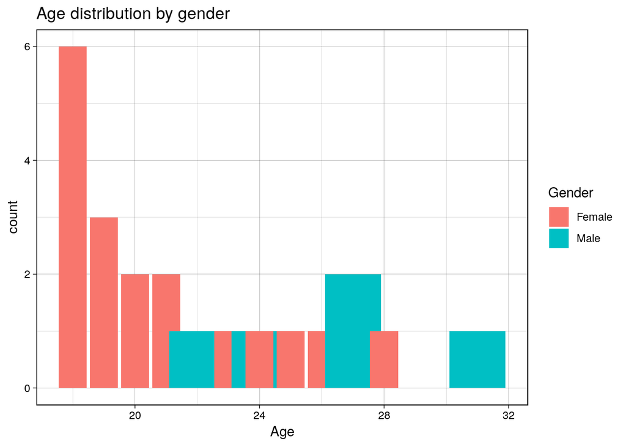

```r
ggplot(demo3, aes(x=Age, fill=Gender)) +
  geom_bar() +
  theme_linedraw() +
  ggtitle("Age distribution by gender")
```

### Loading the data

First, let’s load the Experiment 3 data in ``long’’ format:

```r
exp3l <- read.table("experiment3/BAR_behavioral_data_16.txt", header=T)
```

We need to filter out the `Special` problems, which were performed last and were not part of the task:

```r
exp3l %>% filter(Rules != "Special") -> exp3l
```

Now, a potential problem in this experiment is that participants might time out, so we need to count how many times that happened. Timed-out responses are marked as having a duration of 30,000 ms and 4,000 ms for the Problem and Choice phases, respectively.

### Descriptive statistics

To conduct further analysis, we need to aggregate the data:

```r
group_by(exp3l, Subject) %>%
  summarise(Problem=mean(Problem),
            Choice=mean(Choice),
            Accuracy=mean(Accuracy)) ->
  exp3w
```

In this case, the variables of interest are `Problem` response time, `Choice` response time, and problem `Accuracy`.

```r
vars_of_interest <- c("Problem", "Choice", "Accuracy") # No OS Score
```

As before, we can look at their distribution:

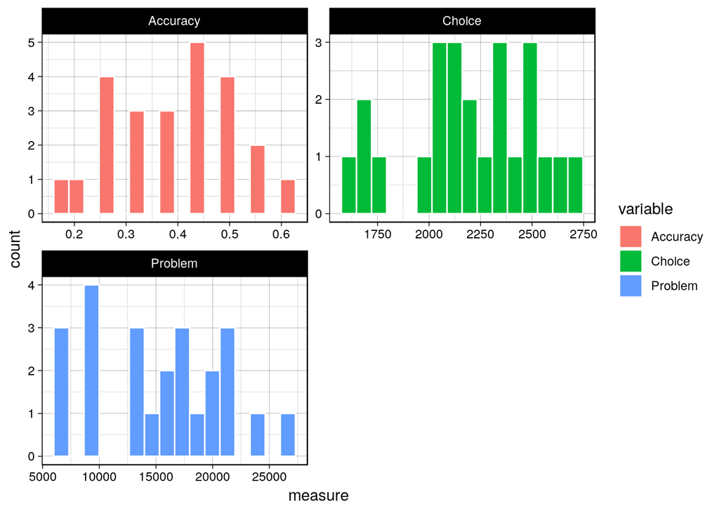

```r
longb3 <- gather(exp3w, variable, measure, vars_of_interest)
ggplot(longb3, aes(measure, fill=variable)) +
  geom_histogram(col=I("white"), bins = 16) +
  facet_wrap( . ~ variable, nrow = 2, scales= "free") +
  theme_linedraw()
```

and their mean values:

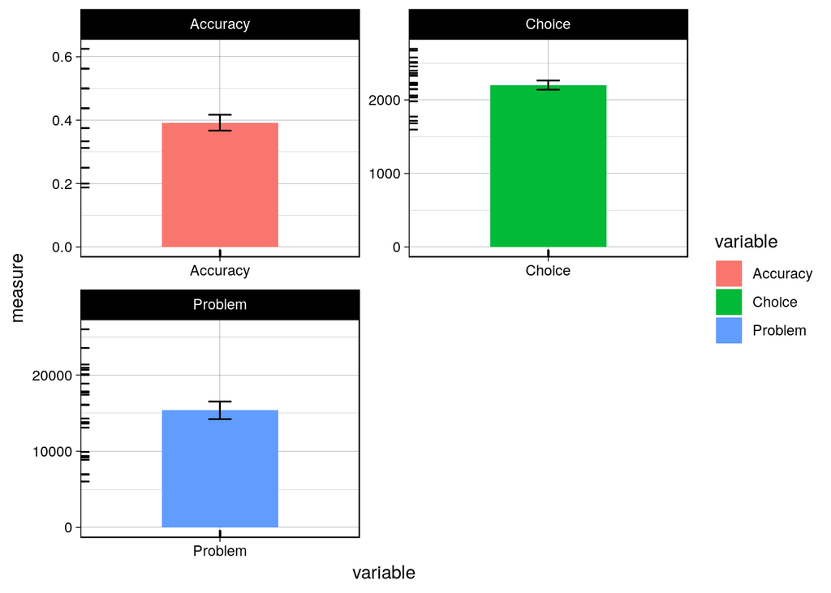

```r
ggplot(longb3, aes(x=variable, y=measure, fill=variable)) +
  stat_summary(fun.data="mean_se", geom = "bar", width=0.5) +
  stat_summary(fun.data="mean_se", geom = "errorbar", width=0.1) +
  geom_rug() +
  facet_wrap( . ~ variable, nrow = 2, scales = "free") +
  theme_linedraw()
```

Here is an overview of the variables as a table:

And, finally, let’s summarize their means and SDs in a table:

```r
longb3 %>%
  group_by(variable) %>%
  summarise(N=length(measure), Mean=mean(measure), SD=sd(measure)) %>%
  kable(digits = 3) %>%
  kable_styling(bootstrap_options = c("striped", "hover"))
```

| variable | N | Mean | SD |
| --- | --- | --- | --- |
| Accuracy | 24 | 0.392 | 0.123 |
| Choice | 24 | 2201.869 | 305.378 |
| Problem | 24 | 15370.309 | 5654.732 |

### Correlations between variables

First, we can examine the correlation matrix between these varibles:

```r
cor(exp3w[vars_of_interest]) %>%
  kable(digits = 3) %>%
  kable_styling(bootstrap_options = c("striped", "hover"))
```

|  | Problem | Choice | Accuracy |
| --- | --- | --- | --- |
| Problem | 1.00 | 0.100 | 0.710 |
| Choice | 0.10 | 1.000 | -0.086 |
| Accuracy | 0.71 | -0.086 | 1.000 |

We can also calculate the correspinding *p*-values:

```r
exp3w[vars_of_interest] %>%
  as.matrix() %>%
  rcorr() -> pvals

pvals$P %>%
  kable(digits = 3) %>%
  kable_styling(bootstrap_options = c("striped", "hover"))
```

|  | Problem | Choice | Accuracy |
| --- | --- | --- | --- |
| Problem | NA | 0.641 | 0.000 |
| Choice | 0.641 | NA | 0.691 |
| Accuracy | 0.000 | 0.691 | NA |

And finally, we can examine the scatterplots of the correlations between variables:

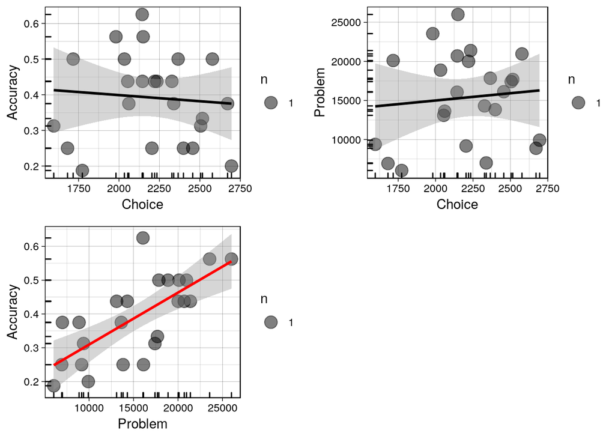

```r
sp1 <- ggplot(exp3w, aes(x = Choice, y = Accuracy)) +
  #stat_bin_hex(bins=16, col="white") +
  geom_count(alpha = 0.5) +
  geom_smooth(method = "lm", formula = y ~ x,
              col="black", fullrange= T) +
  geom_rug() +
  theme_linedraw()

sp2 <- ggplot(exp3w, aes(x = Choice, y = Problem)) +
  #stat_bin_hex(bins = 12, col="white") +
  geom_count(alpha =0.5) +
  geom_smooth(method = "lm", formula = y ~ x,
              col="black", fullrange= T) +
  geom_rug() +
  theme_linedraw()

sp3 <- ggplot(exp3w, aes(x = Problem, y = Accuracy)) +
  #stat_bin_hex(bins = 12, col="white") +
  geom_count(alpha = 0.5) +
  geom_smooth(method = "lm", formula = y ~ x,
              col="red", fullrange= T) +
  geom_rug() +
  theme_linedraw()

grid.arrange(sp1, sp2, sp3, nrow = 2)
```